# stacked_early_CL_classif_ROCAUC

TJ Sipin

2022-08-04

This report gives five different stacked models to predict cutaneous leishmaniasis using data from 2000 to 2013, with each model differing by threshold determining what constitutes low levels and high levels of cutaneous leishmaniasis.

## Seed, Packages, and Data Set

```r
set.seed(123)
library(tidyverse)
library(tidymodels)
library(stacks)
aad <- read_csv('models/data/aad.csv')
load('./data/imp')
aad <- read_csv('models/data/aad.csv')
```

For reproducibility, we use `set.seed(123)`. Then we load in necessary packages and our imputed data set. The original data set had missing values in both the predictors and target variables, so we used a random-forest-based imputation on only a subset of the predictors. We left the target variables alone, as well as the land-use predictors. An NA value in the target variables seemed to mean that the disease was not present in that municipality for that year. On the other hand, an NA value in the land-use variables likely meant that there was no forest found in that municipality. In the later steps, we set all NA values for land-use to 0.

Perhaps a future task may be to identify which observations truly had no cutaneous leishmaniasis or were just not reported. If a municipality does not report the target variable of interest for all years (NA values for all years for that municipality), then remove those observations. If they report at least $n$ non-NAs, where $n$ is a certain threshold of years, then we can maybe impute those values using some technique like the random-forest-based imputation method.

However, for the purpose of simplicity, our predictive models are built on the assumption that all missing values in the target variable meant that there were no cases in that municipality for that year or that the cases were negligible and should be counted as zero.

*Note: all of the target variables are diseases, such as Cutaneous Leishmaniasis, the primary target variable of interest in this report.*

## 30th percentile

First, we clean our data by removing all NA values and 0s of cutaneous leishmaniasis found in our imputed data set. This is because municipalities without cutaneous leishmaniasis are not in our target population. Then we focus only on early data, i.e. observations before 2014. This is because there was a change in how the socioeconomic level of each observation is measured. The two variables `StableLights` and `AvgRad` are complimentary to each other in whether they were reported. `StableLights` was reported only in years before 2014 and `AvgRad` was reported only in years 2014 and up. All early data was handled and predicted on by TJ Sipin, the author of this report, while all later data was handled and predicted on by Lyndsey Umsted.

We both chose our predictors to be `LST_Day`, `NDVI`, `EVI`, `Precip`, `SWOccurrence`, `pland_forest`, `te_forest`, `enn_mn_forest`, `Population`, and the socioeconomic variable. Since all target variables are reported on the continuous scale and we are not using a regression model, we categorize each observation as low levels (0) and high levels (1), splitting at the 30th quantile of the subset of cutaneous leishmaniasis with NAs and zeros removed. The other models are split at the 40th, 50th, 60th, and 70th quantiles, respectively.

```r
# load and split the early data using imputed data

quantile_data <- data %>%
  filter(!is.na(Cutaneous.Leishmaniasis)) %>%
  filter(Cutaneous.Leishmaniasis > 0) %>%
  dplyr::select(Cutaneous.Leishmaniasis)

quantile <- (quantile_data$Cutaneous.Leishmaniasis %>%
  quantile(0.3))[[1]] # PARAMETER

data <- data %>%
  filter(Year < 2014) %>%
  filter(!is.na(Cutaneous.Leishmaniasis)) %>%
  filter(Cutaneous.Leishmaniasis > 0) %>%
  dplyr::select(c('Cutaneous.Leishmaniasis', 'LST_Day', # include LST_Night?
                  'NDVI', 'EVI', 'Precip',
                  'StableLights', 'SWOccurrence', 'pland_forest',
                  'te_forest', 'enn_mn_forest','Population'))


data$pland_forest <- ifelse(is.na(data$pland_forest), 0, data$pland_forest)
data$te_forest <- ifelse(is.na(data$te_forest), 0, data$te_forest)
data$enn_mn_forest <- ifelse(is.na(data$enn_mn_forest), 0, data$enn_mn_forest)

data$Cutaneous.Leishmaniasis <- as.factor(ifelse(data$Cutaneous.Leishmaniasis < quantile, 0, 1))
```

The next step is to split data set into the training and testing subsets and set up a 5-fold cross-validation for when we train our base models.

```r
set.seed(123) # for reproducibility
aad <- aad %>%
  filter(Year < 2014) %>%
  filter(!is.na(Cutaneous.Leishmaniasis)) %>%
  filter(Cutaneous.Leishmaniasis > 0)

split <- initial_split(data)

data_train <- training(split)
data_test_30_temp <- testing(split)
Index_temp <- as.numeric(rownames(data_test_30_temp))
save(Index_temp, file = 'models/stacking/Index_temp')
data_test_30 <-  (aad %>%
                    select(c(colnames(data_test_30_temp))))[Index_temp,] %>%
  subset(!is.na(LST_Day)) %>%
  subset(!is.na(SWOccurrence))


data_test_30$pland_forest <- ifelse(is.na(data_test_30$pland_forest), 0, data_test_30$pland_forest)
data_test_30$te_forest <- ifelse(is.na(data_test_30$te_forest), 0, data_test_30$te_forest)
data_test_30$enn_mn_forest <- ifelse(is.na(data_test_30$enn_mn_forest), 0, data_test_30$enn_mn_forest)

data_test_30$Cutaneous.Leishmaniasis <- as.factor(ifelse(data_test_30$Cutaneous.Leishmaniasis < quantile, 0, 1))

# use a 5-fold cross-validation
folds <- rsample::vfold_cv(data_train,
                           v = 5,
                           strata = Cutaneous.Leishmaniasis)
```

```r
data_test_30_2 <- aad[as.numeric(rownames(data_test_30)),]
library(finalfit)
missing_plot(data_test_30_2)
explanatory = c('LST_Day', # include LST_Night?
                  'NDVI', 'EVI', 'Precip',
                  'StableLights', 'SWOccurrence', 'pland_forest',
                  'te_forest', 'enn_mn_forest','Population')
dependent = 'Cutaneous.Leishmaniasis'
data_test_30_2 %>%
  missing_pairs(dependent, explanatory)

# remove NA for SWO and LST_Day
```

Here, we set up the recipe and workflow using Tidyverse functions.

```r
# set up a basic recipe
data_rec <-
  recipe(Cutaneous.Leishmaniasis ~ LST_Day + NDVI +
           EVI + Precip + StableLights + SWOccurrence + pland_forest +
           te_forest + enn_mn_forest + Population, data = data_train) %>%
  step_dummy(all_nominal() - all_outcomes()) %>%
  step_zv(all_predictors()) %>%
  step_normalize(all_numeric())

# define a minimal workflow
data_wflow <-
  workflow() %>%
  add_recipe(data_rec)

# add metric
metric <- metric_set(sensitivity, accuracy)

# save assessment set predictions and workflow used to fit the resamples
ctrl_grid <- control_stack_grid()
ctrl_res <- control_stack_resamples()
```

The base models we build our stack on are a radial SVM, XGBoost, random forest, and naive bayes. Each are tuned through a grid and cross-validated on our 5-folds.

```r
# models: SVM, XGBoost, RF
## figure out logistic regression for classification

# toy model
log_reg_spec <-
  logistic_reg() %>%
  set_engine('glm')

log_reg_wflow <-
  data_wflow %>%
  add_model(log_reg_spec)

set.seed(123)
log_reg_res <-
  fit_resamples(
    log_reg_wflow,
    resamples = folds,
    metrics = metric,
    control = ctrl_res
  )

# define svm model using parsnip
svm_spec <-
  svm_rbf(
    cost = parsnip::tune(),
    rbf_sigma = parsnip::tune(),
    engine = 'kernlab',
    mode = 'classification'
  )

# add it to a workflow
svm_wflow <-
  data_wflow %>%
  add_model(svm_spec)

# tune cost and rbf_sigma and fit to the 5-fold cv
set.seed(123)
svm_res <-
  tune_grid(
    svm_wflow,
    resamples = folds,
    grid = 5,
    control = ctrl_grid
  )

save(svm_res, file = 'models/stacking/svm_res_early_CL_classif_30')

# define xgboost model using parsnip

set.seed(123)
xgb_spec <-
  boost_tree(
    mtry = tune(),
    trees = tune(),
    min_n = tune(),
    tree_depth = tune(),
    learn_rate = tune(),
    loss_reduction = tune()
  ) %>%
  set_engine('xgboost') %>%
  set_mode('classification')

# add it to a workflow
xgb_wflow <-
  data_wflow %>%
  add_model(xgb_spec)

# tune mtry, trees, min_n, tree_depth, etc.
xgb_res <-
  tune_grid(
    xgb_wflow,
    resamples = folds,
    grid = 5,
    control = ctrl_grid
  )

save(xgb_res, file = 'models/stacking/xgb_res_early_CL_classif_30')


# define rf model using parsnip

set.seed(123)
rf_spec <-
  rand_forest(
    mtry = tune(),
    trees = tune(),
    min_n = tune()
  ) %>%
  set_engine('ranger') %>%
  set_mode('classification')

# add it to a workflow
rf_wflow <-
  data_wflow %>%
  add_model(rf_spec)

# tune mtry, trees, min_n
rf_res <-
  tune_grid(
    rf_wflow,
    resamples = folds,
    grid = 5,
    control = ctrl_grid
  )


save(rf_res, file = 'models/stacking/rf_res_early_CL_classif_30')
#


library(discrim) # for engine = 'naivebayes' or 'klaR'
library(agua) # for engine = 'h2o'

# define nb model using parsnip
nb_spec <-
  naive_Bayes(
    mode = 'classification',
    smoothness = tune(),
    Laplace = tune(),
    engine = 'naivebayes'
  )



# add it to a workflow
nb_wflow <-
  data_wflow %>%
  add_model(nb_spec)

# tune smoothness and Laplace
nb_res <-
  tune_grid(
    nb_wflow,
    resamples = folds,
    grid = 5,
    control = ctrl_grid
  )

save(nb_res, file = 'models/stacking/nb_res_early_CL_classif_30')
```

Finally, we build our stacked model based on the best performing base model candidates.

```r
load(file = 'models/stacking/svm_res_early_CL_classif_30')
load(file = 'models/stacking/xgb_res_early_CL_classif_30')
load(file = 'models/stacking/rf_res_early_CL_classif_30')
load(file = 'models/stacking/nb_res_early_CL_classif_30')


data_st_30 <-
  stacks() %>%
  add_candidates(xgb_res) %>%
  add_candidates(rf_res) %>%
  add_candidates(svm_res) %>%
  add_candidates(nb_res)


save(data_st_30, file = 'models/stacking/data_st_early_CL_classif_30')

# creating a model stack
## ready to evaluate how it is that we need to combine predictions from
## each candidate ensemble member

model_st_30 <-
  data_st_30 %>%
  blend_predictions()

model_st_30 <-
  model_st_30 %>%
  fit_members()

save(model_st_30, file = 'models/stacking/model_st_early_CL_classif_30')
load('models/stacking/model_st_early_CL_classif_30')

# set.seed(123)
# data_test_30 <- testing(split)
#
data_test_30 <-
  data_test_30 %>%
  bind_cols(predict(model_st_30, .))

save(data_test_30, file = 'models/stacking/data_test_early_CL_classif_30')


# confusion matrix for stacks
conf_mat_early_CL_classif_30 <- caret::confusionMatrix(data = data_test_30$.pred_class,
                                                       reference = data_test_30$Cutaneous.Leishmaniasis,
                                                       positive = '1')

save(conf_mat_early_CL_classif_30, file = 'models/stacking/conf_mat_early_CL_classif_30')

# confusion matrix for base models

member_preds <-
  data_test_30 %>%
  dplyr::select(Cutaneous.Leishmaniasis) %>%
  bind_cols(
    predict(
      model_st_30,
      data_test_30,
      members = TRUE
    )
  )

colnames(member_preds) %>%
  map_dfr(
    .f = sensitivity,
    truth = as.factor(Cutaneous.Leishmaniasis),
    data = member_preds
  ) %>%
  mutate(member = colnames(member_preds))
```

The rest of the models are built similarly, with only the quantile threshold as a parameter.

## All Confusion Matrices

### 30th percentile

```
## $positive
## [1] "1"
##
## $table
##           Reference
## Prediction    0    1
##          0 1400  305
##          1  803 4892
##
## $overall
##       Accuracy          Kappa  AccuracyLower  AccuracyUpper   AccuracyNull
##   8.502703e-01   6.169846e-01   8.419354e-01   8.583282e-01   7.022973e-01
## AccuracyPValue  McnemarPValue
##  3.928430e-194   2.073914e-50
##
## $byClass
##          Sensitivity          Specificity       Pos Pred Value
##            0.9413123            0.6354970            0.8589991
##       Neg Pred Value            Precision               Recall
##            0.8211144            0.8589991            0.9413123
##                   F1           Prevalence       Detection Rate
##            0.8982740            0.7022973            0.6610811
## Detection Prevalence    Balanced Accuracy
##            0.7695946            0.7884047
```

### 40th percentile

```
## $positive
## [1] "1"
##
## $table
##           Reference
## Prediction    0    1
##          0 2226  495
##          1  746 3933
##
## $overall
##       Accuracy          Kappa  AccuracyLower  AccuracyUpper   AccuracyNull
##   8.322973e-01   6.461741e-01   8.235871e-01   8.407449e-01   5.983784e-01
## AccuracyPValue  McnemarPValue
##   0.000000e+00   1.278062e-12
##
## $byClass
##          Sensitivity          Specificity       Pos Pred Value
##            0.8882114            0.7489906            0.8405642
##       Neg Pred Value            Precision               Recall
##            0.8180816            0.8405642            0.8882114
##                   F1           Prevalence       Detection Rate
##            0.8637312            0.5983784            0.5314865
## Detection Prevalence    Balanced Accuracy
##            0.6322973            0.8186010
```

### 50th percentile

```
## $positive
## [1] "1"
##
## $table
##           Reference
## Prediction    0    1
##          0 3072  743
##          1  616 2969
##
## $overall
##       Accuracy          Kappa  AccuracyLower  AccuracyUpper   AccuracyNull
##   0.8163513514   0.6327397238   0.8073378251   0.8251149571   0.5016216216
## AccuracyPValue  McnemarPValue
##   0.0000000000   0.0006310362
##
## $byClass
##          Sensitivity          Specificity       Pos Pred Value
##            0.7998384            0.8329718            0.8281729
##       Neg Pred Value            Precision               Recall
##            0.8052425            0.8281729            0.7998384
##                   F1           Prevalence       Detection Rate
##            0.8137591            0.5016216            0.4012162
## Detection Prevalence    Balanced Accuracy
##            0.4844595            0.8164051
```

### 60th percentile

```
## $positive
## [1] "1"
##
## $table
##           Reference
## Prediction    0    1
##          0 3902  788
##          1  528 2182
##
## $overall
##       Accuracy          Kappa  AccuracyLower  AccuracyUpper   AccuracyNull
##   8.221622e-01   6.245016e-01   8.132561e-01   8.308137e-01   5.986486e-01
## AccuracyPValue  McnemarPValue
##   0.000000e+00   9.362598e-13
##
## $byClass
##          Sensitivity          Specificity       Pos Pred Value
##            0.7346801            0.8808126            0.8051661
##       Neg Pred Value            Precision               Recall
##            0.8319829            0.8051661            0.7346801
##                   F1           Prevalence       Detection Rate
##            0.7683099            0.4013514            0.2948649
## Detection Prevalence    Balanced Accuracy
##            0.3662162            0.8077464
```

### 70th percentile

```
## $positive
## [1] "1"
##
## $table
##           Reference
## Prediction    0    1
##          0 4788  737
##          1  405 1470
##
## $overall
##       Accuracy          Kappa  AccuracyLower  AccuracyUpper   AccuracyNull
##   8.456757e-01   6.146563e-01   8.372412e-01   8.538369e-01   7.017568e-01
## AccuracyPValue  McnemarPValue
##  1.298682e-182   1.185484e-22
##
## $byClass
##          Sensitivity          Specificity       Pos Pred Value
##            0.6660625            0.9220104            0.7840000
##       Neg Pred Value            Precision               Recall
##            0.8666063            0.7840000            0.6660625
##                   F1           Prevalence       Detection Rate
##            0.7202352            0.2982432            0.1986486
## Detection Prevalence    Balanced Accuracy
##            0.2533784            0.7940365
```

## ROC AUC Graphs

Now, we show the ROC AUC graphs

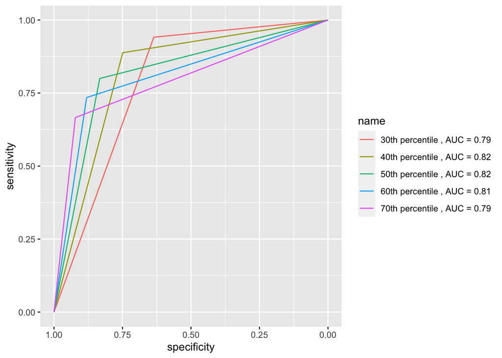

```r
library(tidyverse)
library(pROC)
library(dplyr)
library(ggplot2)
library(plotROC)

load(file = 'models/stacking/data_test_early_CL_classif_30')
load(file = 'models/stacking/data_test_early_CL_classif_40')
load(file = 'models/stacking/data_test_early_CL_classif_50')
load(file = 'models/stacking/data_test_early_CL_classif_60')
load(file = 'models/stacking/data_test_early_CL_classif_70')

roc_30 <- roc(data_test_30$Cutaneous.Leishmaniasis,
    data_test_30$.pred_class %>% as.numeric(),
    print.auc = T)
roc_40 <- roc(data_test_40$Cutaneous.Leishmaniasis,
    data_test_40$.pred_class %>% as.ordered(),
    print.auc = T)
roc_50 <- roc(data_test_50$Cutaneous.Leishmaniasis,
    data_test_50$.pred_class %>% as.ordered(),
    print.auc = T)
roc_60 <- roc(data_test_60$Cutaneous.Leishmaniasis,
    data_test_60$.pred_class %>% as.ordered())
roc_70 <- roc(data_test_70$Cutaneous.Leishmaniasis,
    data_test_70$.pred_class %>% as.ordered())


roc_list <- list('30th percentile' = roc_30,
           '40th percentile' = roc_40,
           '50th percentile' = roc_50,
           '60th percentile' = roc_60,
           '70th percentile' = roc_70)

# extract AUC
data.auc <- roc_list %>%
  map(~tibble(AUC = .x$auc)) %>%
  bind_rows(.id = 'name')

# generate labels
data.labels <- data.auc %>%
  mutate(label_long = paste0(name, ' , AUC = ',
                             paste(round(AUC,2))),
         label_AUC = paste0('AUC = ',
                            paste(round(AUC,2))))

pROC::ggroc(roc_list,
           legacy.axes = F) +
  scale_color_discrete(labels = data.labels$label_long)
```

## Misclassifications

Now we look at the observations in which our model wrongly classified observations. Perhaps we can develop a second model trained on the misclassified cases to further improve our model.

```r
# to get true levels of CL again

load('./data/imp')
load('models/stacking/Index_temp')
aad <- read_csv('models/data/aad.csv')


data <- data %>%
  filter(Year < 2014) %>%
  filter(!is.na(Cutaneous.Leishmaniasis)) %>%
  filter(Cutaneous.Leishmaniasis > 0) %>%
  dplyr::select(c('Cutaneous.Leishmaniasis', 'LST_Day', # include LST_Night?
                  'NDVI', 'EVI', 'Precip',
                  'StableLights', 'SWOccurrence', 'pland_forest',
                  'te_forest', 'enn_mn_forest','Population'))


data$pland_forest <- ifelse(is.na(data$pland_forest), 0, data$pland_forest)
data$te_forest <- ifelse(is.na(data$te_forest), 0, data$te_forest)
data$enn_mn_forest <- ifelse(is.na(data$enn_mn_forest), 0, data$enn_mn_forest)

set.seed(123)
split_t <- initial_split(data)
training_t <- training(split_t)
testing_t_temp <- testing(split_t)

aad_clean <- aad %>%
  filter(Year < 2014) %>%
  filter(!is.na(Cutaneous.Leishmaniasis)) %>%
  filter(Cutaneous.Leishmaniasis > 0)

testing_t <- (aad_clean %>%
                    select(c(colnames(testing_t_temp))))[Index_temp,] %>%
  subset(!is.na(LST_Day)) %>%
  subset(!is.na(SWOccurrence))


mis_40 <- data_test_40 %>%
  mutate(CL = testing_t$Cutaneous.Leishmaniasis) %>%
  filter((data_test_40$Cutaneous.Leishmaniasis != data_test_40$.pred_class)) %>%
  mutate(Case = which((data_test_40$.pred_class != data_test_40$Cutaneous.Leishmaniasis)))




# correlation heatmap
library(reshape2)

# helper function for reordering the correlation matrix
reorder_cormat <- function(cormat){
  # Use correlation between variables as distance
  dd <- as.dist((1-cormat)/2)
  hc <- hclust(dd)
  cormat <-cormat[hc$order, hc$order]
}




# heat maps for original, misclassified, and correctly classified
aad <- read_csv('models/data/aad.csv')
aad_clean <- (aad %>%
          select(c(Cutaneous.Leishmaniasis, LST_Day, NDVI,
                   EVI, Precip, StableLights,
                   SWOccurrence, pland_forest, te_forest,
                   enn_mn_forest, Population))) %>%
  subset(!is.na(LST_Day)) %>%
  subset(!is.na(SWOccurrence)) %>%
  subset(!is.na(StableLights)) %>%
  subset(!is.na(Cutaneous.Leishmaniasis)) %>%
  subset(Cutaneous.Leishmaniasis > 0)
aad_clean$pland_forest <- ifelse(is.na(aad_clean$pland_forest), 0, aad_clean$pland_forest)
aad_clean$te_forest <- ifelse(is.na(aad_clean$te_forest), 0, aad_clean$te_forest)
aad_clean$enn_mn_forest <- ifelse(is.na(aad_clean$enn_mn_forest), 0, aad_clean$enn_mn_forest)

cormat_data <- cor(aad_clean) %>% round(2)
melted_cormat_data <- melt(cormat_data)
heatmap_aad <- ggplot(data = melted_cormat_data,
       aes(x = Var1,
           y = Var2,
           fill = value)) +
  geom_tile(color = 'white') +
  scale_fill_gradient2(low = 'blue', high = 'red', mid = 'white',
                       midpoint = 0, limit = c(-1,1), space = 'Lab',
                       name = 'Pearson\nCorrelation') +
  theme(axis.text.x = element_text(angle = 45, vjust = 1,
                                   size = 12, hjust = 1)) +
  coord_fixed() +
  ggtitle('Original data')

save(heatmap_aad, file = "models/stacking/heatmap_aad")

# misclassified

cormat_mis_40 <- round(cor(mis_40 %>%
                             mutate(Cutaneous.Leishmaniasis = CL) %>%
                             select(-c(CL, Case,.pred_class))), 2)
melted_cormat_mis_40 <- melt(cormat_mis_40)
heatmap_mis_40 <- ggplot(data = melted_cormat_mis_40,
                         aes(x = Var1,
                             y = Var2,
                             fill = value)) +
  geom_tile(color = 'white') +
  scale_fill_gradient2(low = 'blue', high = 'red', mid = 'white',
                       midpoint = 0, limit = c(-1,1), space = 'Lab',
                       name = 'Pearson\nCorrelation') +
  theme(axis.text.x = element_text(angle = 45, vjust = 1,
                                   size = 12, hjust = 1)) +
  coord_fixed() +
  ggtitle('Incorrectly Classified')

save(heatmap_mis_40, file = "models/stacking/heatmap_mis_40")

# correctly classified

correct_40 <- data_test_40 %>%
  mutate(CL = testing_t$Cutaneous.Leishmaniasis) %>%
  filter((data_test_40$Cutaneous.Leishmaniasis == data_test_40$.pred_class)) %>%
  mutate(Case = which((data_test_40$.pred_class == data_test_40$Cutaneous.Leishmaniasis)))

cormat_correct_40 <- round(cor(correct_40 %>%
                             mutate(Cutaneous.Leishmaniasis = CL) %>%
                             select(-c(CL, Case,.pred_class))), 2)

melted_cormat_correct_40 <- melt(cormat_correct_40)

heatmap_correct_40 <- ggplot(data = melted_cormat_correct_40,
                             aes(x = Var1,
                                 y = Var2,
                                 fill = value)) +
  geom_tile(color = 'white') +
  scale_fill_gradient2(low = 'blue', high = 'red', mid = 'white',
                       midpoint = 0, limit = c(-1,1), space = 'Lab',
                       name = 'Pearson\nCorrelation') +
  theme(axis.text.x = element_text(angle = 45, vjust = 1,
                                   size = 12, hjust = 1)) +
  coord_fixed() +
  ggtitle('Correctly Classified')
save(heatmap_correct_40, file = "models/stacking/heatmap_correct_40")
```

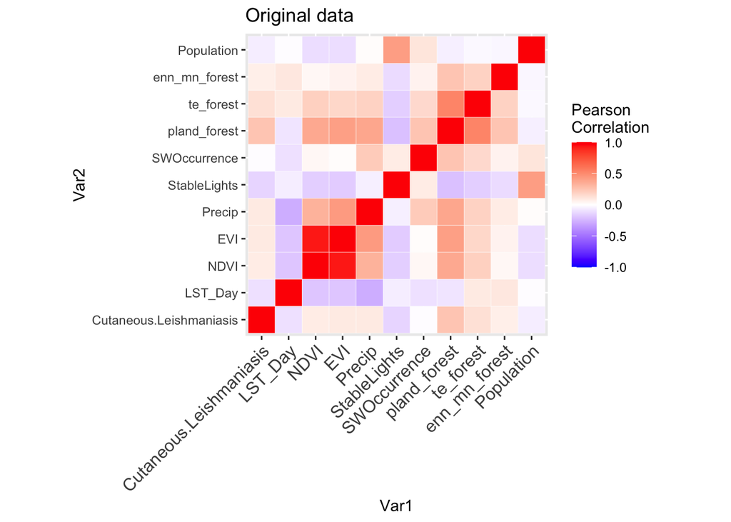

```r
load("models/stacking/heatmap_aad")
load("models/stacking/heatmap_mis_40")
load("models/stacking/heatmap_correct_40")


heatmap_aad
```

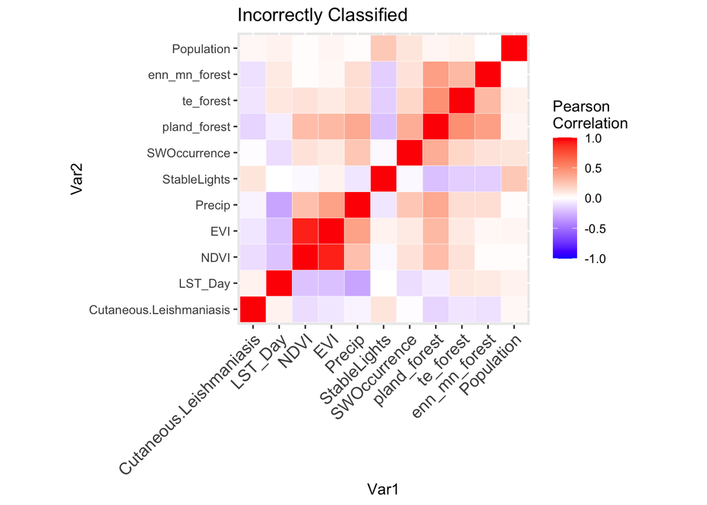

```r
heatmap_mis_40
```

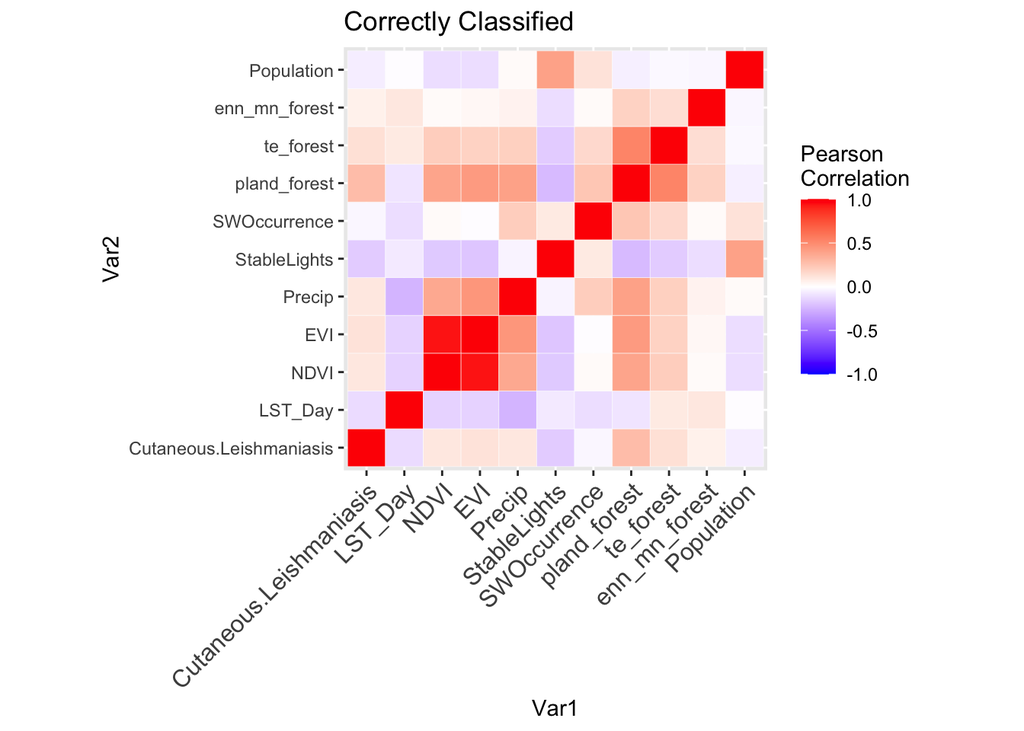

```r
heatmap_correct_40
```

We see here that the correlation between cutaneous leishmaniasis and all other variables is opposite for the incorrectly classified data compared to the original and correctly classified data.

# Appendix: All code for this report

```r
knitr::opts_chunk$set(echo = T,
                      cache = F,
                      eval = F,
                      results = 'show',
                      warning = F,
                      message = F)

set.seed(123)
library(tidyverse)
library(tidymodels)
library(stacks)
aad <- read_csv('models/data/aad.csv')
load('./data/imp')
aad <- read_csv('models/data/aad.csv')
# load and split the early data using imputed data

quantile_data <- data %>%
  filter(!is.na(Cutaneous.Leishmaniasis)) %>%
  filter(Cutaneous.Leishmaniasis > 0) %>%
  dplyr::select(Cutaneous.Leishmaniasis)

quantile <- (quantile_data$Cutaneous.Leishmaniasis %>%
  quantile(0.3))[[1]] # PARAMETER

data <- data %>%
  filter(Year < 2014) %>%
  filter(!is.na(Cutaneous.Leishmaniasis)) %>%
  filter(Cutaneous.Leishmaniasis > 0) %>%
  dplyr::select(c('Cutaneous.Leishmaniasis', 'LST_Day', # include LST_Night?
                  'NDVI', 'EVI', 'Precip',
                  'StableLights', 'SWOccurrence', 'pland_forest',
                  'te_forest', 'enn_mn_forest','Population'))


data$pland_forest <- ifelse(is.na(data$pland_forest), 0, data$pland_forest)
data$te_forest <- ifelse(is.na(data$te_forest), 0, data$te_forest)
data$enn_mn_forest <- ifelse(is.na(data$enn_mn_forest), 0, data$enn_mn_forest)

data$Cutaneous.Leishmaniasis <- as.factor(ifelse(data$Cutaneous.Leishmaniasis < quantile, 0, 1))
set.seed(123) # for reproducibility
aad <- aad %>%
  filter(Year < 2014) %>%
  filter(!is.na(Cutaneous.Leishmaniasis)) %>%
  filter(Cutaneous.Leishmaniasis > 0)

split <- initial_split(data)

data_train <- training(split)
data_test_30_temp <- testing(split)
Index_temp <- as.numeric(rownames(data_test_30_temp))
save(Index_temp, file = 'models/stacking/Index_temp')
data_test_30 <-  (aad %>%
                    select(c(colnames(data_test_30_temp))))[Index_temp,] %>%
  subset(!is.na(LST_Day)) %>%
  subset(!is.na(SWOccurrence))


data_test_30$pland_forest <- ifelse(is.na(data_test_30$pland_forest), 0, data_test_30$pland_forest)
data_test_30$te_forest <- ifelse(is.na(data_test_30$te_forest), 0, data_test_30$te_forest)
data_test_30$enn_mn_forest <- ifelse(is.na(data_test_30$enn_mn_forest), 0, data_test_30$enn_mn_forest)

data_test_30$Cutaneous.Leishmaniasis <- as.factor(ifelse(data_test_30$Cutaneous.Leishmaniasis < quantile, 0, 1))

# use a 5-fold cross-validation
folds <- rsample::vfold_cv(data_train,
                           v = 5,
                           strata = Cutaneous.Leishmaniasis)
data_test_30_2 <- aad[as.numeric(rownames(data_test_30)),]
library(finalfit)
missing_plot(data_test_30_2)
explanatory = c('LST_Day', # include LST_Night?
                  'NDVI', 'EVI', 'Precip',
                  'StableLights', 'SWOccurrence', 'pland_forest',
                  'te_forest', 'enn_mn_forest','Population')
dependent = 'Cutaneous.Leishmaniasis'
data_test_30_2 %>%
  missing_pairs(dependent, explanatory)

# remove NA for SWO and LST_Day
# set up a basic recipe
data_rec <-
  recipe(Cutaneous.Leishmaniasis ~ LST_Day + NDVI +
           EVI + Precip + StableLights + SWOccurrence + pland_forest +
           te_forest + enn_mn_forest + Population, data = data_train) %>%
  step_dummy(all_nominal() - all_outcomes()) %>%
  step_zv(all_predictors()) %>%
  step_normalize(all_numeric())

# define a minimal workflow
data_wflow <-
  workflow() %>%
  add_recipe(data_rec)

# add metric
metric <- metric_set(sensitivity, accuracy)

# save assessment set predictions and workflow used to fit the resamples
ctrl_grid <- control_stack_grid()
ctrl_res <- control_stack_resamples()
# models: SVM, XGBoost, RF
## figure out logistic regression for classification

# toy model
log_reg_spec <-
  logistic_reg() %>%
  set_engine('glm')

log_reg_wflow <-
  data_wflow %>%
  add_model(log_reg_spec)

set.seed(123)
log_reg_res <-
  fit_resamples(
    log_reg_wflow,
    resamples = folds,
    metrics = metric,
    control = ctrl_res
  )

# define svm model using parsnip
svm_spec <-
  svm_rbf(
    cost = parsnip::tune(),
    rbf_sigma = parsnip::tune(),
    engine = 'kernlab',
    mode = 'classification'
  )

# add it to a workflow
svm_wflow <-
  data_wflow %>%
  add_model(svm_spec)

# tune cost and rbf_sigma and fit to the 5-fold cv
set.seed(123)
svm_res <-
  tune_grid(
    svm_wflow,
    resamples = folds,
    grid = 5,
    control = ctrl_grid
  )

save(svm_res, file = 'models/stacking/svm_res_early_CL_classif_30')

# define xgboost model using parsnip

set.seed(123)
xgb_spec <-
  boost_tree(
    mtry = tune(),
    trees = tune(),
    min_n = tune(),
    tree_depth = tune(),
    learn_rate = tune(),
    loss_reduction = tune()
  ) %>%
  set_engine('xgboost') %>%
  set_mode('classification')

# add it to a workflow
xgb_wflow <-
  data_wflow %>%
  add_model(xgb_spec)

# tune mtry, trees, min_n, tree_depth, etc.
xgb_res <-
  tune_grid(
    xgb_wflow,
    resamples = folds,
    grid = 5,
    control = ctrl_grid
  )

save(xgb_res, file = 'models/stacking/xgb_res_early_CL_classif_30')


# define rf model using parsnip

set.seed(123)
rf_spec <-
  rand_forest(
    mtry = tune(),
    trees = tune(),
    min_n = tune()
  ) %>%
  set_engine('ranger') %>%
  set_mode('classification')

# add it to a workflow
rf_wflow <-
  data_wflow %>%
  add_model(rf_spec)

# tune mtry, trees, min_n
rf_res <-
  tune_grid(
    rf_wflow,
    resamples = folds,
    grid = 5,
    control = ctrl_grid
  )


save(rf_res, file = 'models/stacking/rf_res_early_CL_classif_30')
#


library(discrim) # for engine = 'naivebayes' or 'klaR'
library(agua) # for engine = 'h2o'

# define nb model using parsnip
nb_spec <-
  naive_Bayes(
    mode = 'classification',
    smoothness = tune(),
    Laplace = tune(),
    engine = 'naivebayes'
  )



# add it to a workflow
nb_wflow <-
  data_wflow %>%
  add_model(nb_spec)

# tune smoothness and Laplace
nb_res <-
  tune_grid(
    nb_wflow,
    resamples = folds,
    grid = 5,
    control = ctrl_grid
  )

save(nb_res, file = 'models/stacking/nb_res_early_CL_classif_30')
load(file = 'models/stacking/svm_res_early_CL_classif_30')
load(file = 'models/stacking/xgb_res_early_CL_classif_30')
load(file = 'models/stacking/rf_res_early_CL_classif_30')
load(file = 'models/stacking/nb_res_early_CL_classif_30')
```

```r
data_st_30 <-
  stacks() %>%
  add_candidates(xgb_res) %>%
  add_candidates(rf_res) %>%
  add_candidates(svm_res) %>%
  add_candidates(nb_res)


save(data_st_30, file = 'models/stacking/data_st_early_CL_classif_30')

# creating a model stack
## ready to evaluate how it is that we need to combine predictions from
## each candidate ensemble member

model_st_30 <-
  data_st_30 %>%
  blend_predictions()

model_st_30 <-
  model_st_30 %>%
  fit_members()

save(model_st_30, file = 'models/stacking/model_st_early_CL_classif_30')
load('models/stacking/model_st_early_CL_classif_30')

# set.seed(123)
# data_test_30 <- testing(split)
#
data_test_30 <-
  data_test_30 %>%
  bind_cols(predict(model_st_30, .))

save(data_test_30, file = 'models/stacking/data_test_early_CL_classif_30')


# confusion matrix for stacks
conf_mat_early_CL_classif_30 <- caret::confusionMatrix(data = data_test_30$.pred_class,
                                                       reference = data_test_30$Cutaneous.Leishmaniasis,
                                                       positive = '1')

save(conf_mat_early_CL_classif_30, file = 'models/stacking/conf_mat_early_CL_classif_30')

# confusion matrix for base models

member_preds <-
  data_test_30 %>%
  dplyr::select(Cutaneous.Leishmaniasis) %>%
  bind_cols(
    predict(
      model_st_30,
      data_test_30,
      members = TRUE
    )
  )

colnames(member_preds) %>%
  map_dfr(
    .f = sensitivity,
    truth = as.factor(Cutaneous.Leishmaniasis),
    data = member_preds
  ) %>%
  mutate(member = colnames(member_preds))
# helper packages
library(tidyverse)
library(tidymodels)
library(stacks)


# load and split the early data using imputed data
load('./data/imp')
aad <- read_csv('models/data/aad.csv')


quantile_data <- data %>%
  filter(!is.na(Cutaneous.Leishmaniasis)) %>%
  filter(Cutaneous.Leishmaniasis > 0) %>%
  dplyr::select(Cutaneous.Leishmaniasis)

quantile <- (quantile_data$Cutaneous.Leishmaniasis %>%
  quantile(0.4))[[1]] # PARAMETER

data <- data %>%
  filter(Year < 2014) %>%
  filter(!is.na(Cutaneous.Leishmaniasis)) %>%
  filter(Cutaneous.Leishmaniasis > 0) %>%
  dplyr::select(c('Cutaneous.Leishmaniasis', 'LST_Day', # include LST_Night?
                  'NDVI', 'EVI', 'Precip',
                  'StableLights', 'SWOccurrence', 'pland_forest',
                  'te_forest', 'enn_mn_forest','Population'))


data$pland_forest <- ifelse(is.na(data$pland_forest), 0, data$pland_forest)
data$te_forest <- ifelse(is.na(data$te_forest), 0, data$te_forest)
data$enn_mn_forest <- ifelse(is.na(data$enn_mn_forest), 0, data$enn_mn_forest)

data$Cutaneous.Leishmaniasis <- as.factor(ifelse(data$Cutaneous.Leishmaniasis < quantile, 0, 1))

set.seed(123) # for reproducibility
aad <- aad %>%
  filter(Year < 2014) %>%
  filter(!is.na(Cutaneous.Leishmaniasis)) %>%
  filter(Cutaneous.Leishmaniasis > 0)

split <- initial_split(data)

data_train <- training(split)
data_test_40_temp <- testing(split)

data_test_40 <-  (aad %>%
                    select(c(colnames(data_test_40_temp))))[Index_temp,] %>%
  subset(!is.na(LST_Day)) %>%
  subset(!is.na(SWOccurrence))


data_test_40$pland_forest <- ifelse(is.na(data_test_40$pland_forest), 0, data_test_40$pland_forest)
data_test_40$te_forest <- ifelse(is.na(data_test_40$te_forest), 0, data_test_40$te_forest)
data_test_40$enn_mn_forest <- ifelse(is.na(data_test_40$enn_mn_forest), 0, data_test_40$enn_mn_forest)

data_test_40$Cutaneous.Leishmaniasis <- as.factor(ifelse(data_test_40$Cutaneous.Leishmaniasis < quantile, 0, 1))

# use a 5-fold cross-validation
folds <- rsample::vfold_cv(data_train,
                           v = 5,
                           strata = Cutaneous.Leishmaniasis)

# set up a basic recipe
data_rec <-
  recipe(Cutaneous.Leishmaniasis ~ LST_Day + NDVI +
           EVI + Precip + StableLights + SWOccurrence + pland_forest +
           te_forest + enn_mn_forest + Population, data = data_train) %>%
  step_dummy(all_nominal() - all_outcomes()) %>%
  step_zv(all_predictors()) %>%
  step_normalize(all_numeric())

# define a minimal workflow
data_wflow <-
  workflow() %>%
  add_recipe(data_rec)

# add metric
metric <- metric_set(sensitivity, accuracy)

# save assessment set predictions and workflow used to fit the resamples
ctrl_grid <- control_stack_grid()
ctrl_res <- control_stack_resamples()

# models: SVM, XGBoost, RF
## models to try: logistic regression

# toy model
log_reg_spec <-
  logistic_reg() %>%
  set_engine('glm')

log_reg_wflow <-
  data_wflow %>%
  add_model(log_reg_spec)

set.seed(123)
log_reg_res <-
  fit_resamples(
    log_reg_wflow,
    resamples = folds,
    metrics = metric,
    control = ctrl_res
  )

# define svm model using parsnip
svm_spec <-
  svm_rbf(
    cost = parsnip::tune(),
    rbf_sigma = parsnip::tune(),
    engine = 'kernlab',
    mode = 'classification'
  )

# add it to a workflow
svm_wflow <-
  data_wflow %>%
  add_model(svm_spec)

# tune cost and rbf_sigma and fit to the 5-fold cv
set.seed(123)
svm_res <-
  tune_grid(
    svm_wflow,
    resamples = folds,
    grid = 5,
    control = ctrl_grid
  )

save(svm_res, file = 'models/stacking/svm_res_early_CL_classif_40')

# define xgboost model using parsnip

set.seed(123)
xgb_spec <-
  boost_tree(
    mtry = tune(),
    trees = tune(),
    min_n = tune(),
    tree_depth = tune(),
    learn_rate = tune(),
    loss_reduction = tune()
  ) %>%
  set_engine('xgboost') %>%
  set_mode('classification')

# add it to a workflow
xgb_wflow <-
  data_wflow %>%
  add_model(xgb_spec)

# tune mtry, trees, min_n, tree_depth, etc.
xgb_res <-
  tune_grid(
    xgb_wflow,
    resamples = folds,
    grid = 5,
    control = ctrl_grid
  )

save(xgb_res, file = 'models/stacking/xgb_res_early_CL_classif_40')
#

# define rf model using parsnip

set.seed(123)
rf_spec <-
  rand_forest(
    mtry = tune(),
    trees = tune(),
    min_n = tune()
  ) %>%
  set_engine('ranger') %>%
  set_mode('classification')

# add it to a workflow
rf_wflow <-
  data_wflow %>%
  add_model(rf_spec)
```

```r
# tune mtry, trees, min_n
rf_res <-
  tune_grid(
    rf_wflow,
    resamples = folds,
    grid = 5,
    control = ctrl_grid
  )


save(rf_res, file = 'models/stacking/rf_res_early_CL_classif_40')
#


library(discrim) # for engine = 'naivebayes' or 'klaR'
library(agua) # for engine = 'h2o'

# define nb model using parsnip
nb_spec <-
  naive_Bayes(
    mode = 'classification',
    smoothness = tune(),
    Laplace = tune(),
    engine = 'naivebayes'
  )



# add it to a workflow
nb_wflow <-
  data_wflow %>%
  add_model(nb_spec)

# tune smoothness and Laplace
nb_res <-
  tune_grid(
    nb_wflow,
    resamples = folds,
    grid = 5,
    control = ctrl_grid
  )

save(nb_res, file = 'models/stacking/nb_res_early_CL_classif_40')

load(file = 'models/stacking/svm_res_early_CL_classif_40')
load(file = 'models/stacking/xgb_res_early_CL_classif_40')
load(file = 'models/stacking/rf_res_early_CL_classif_40')
load(file = 'models/stacking/nb_res_early_CL_classif_40')


data_st_40 <-
  stacks() %>%
  add_candidates(xgb_res) %>%
  add_candidates(rf_res) %>%
  add_candidates(svm_res) %>%
  add_candidates(nb_res)


save(data_st_40, file = 'models/stacking/data_st_early_CL_classif_40')
load('models/stacking/data_st_early_CL_classif_40')

# creating a model stack
## ready to evaluate how it is that we need to combine predictions from
## each candidate ensembe member

model_st_40 <-
  data_st_40 %>%
  blend_predictions()

model_st_40 <-
  model_st_40 %>%
  fit_members()

save(model_st_40, file = 'models/stacking/model_st_early_CL_classif_40')

load('models/stacking/model_st_early_CL_classif_40')

data_test_40 <-
  data_test_40 %>%
  bind_cols(predict(model_st_40, .))

save(data_test_40, file = 'models/stacking/data_test_early_CL_classif_40')


# confusion matrix for stacks
conf_mat_early_CL_classif_40 <- caret::confusionMatrix(data = data_test_40$.pred_class,
                                                       reference = data_test_40$Cutaneous.Leishmaniasis,
                                                       positive = '1')

save(conf_mat_early_CL_classif_40, file = 'models/stacking/conf_mat_early_CL_classif_40')

# confusion matrix for base models

member_preds <-
  data_test_40 %>%
  dplyr::select(Cutaneous.Leishmaniasis) %>%
  bind_cols(
    predict(
      model_st_40,
      data_test_40,
      members = TRUE
    )
  )

# helper packages
library(tidyverse)
library(tidymodels)
library(stacks)


# load and split the early data using imputed data
load('./data/imp')
aad <- read_csv('models/data/aad.csv')


quantile_data <- data %>%
  filter(!is.na(Cutaneous.Leishmaniasis)) %>%
  filter(Cutaneous.Leishmaniasis > 0) %>%
  dplyr::select(Cutaneous.Leishmaniasis)

quantile <- (quantile_data$Cutaneous.Leishmaniasis %>%
  quantile(0.5))[[1]] # PARAMETER

data <- data %>%
  filter(Year < 2014) %>%
  filter(!is.na(Cutaneous.Leishmaniasis)) %>%
  filter(Cutaneous.Leishmaniasis > 0) %>%
  dplyr::select(c('Cutaneous.Leishmaniasis', 'LST_Day', # include LST_Night?
                  'NDVI', 'EVI', 'Precip',
                  'StableLights', 'SWOccurrence', 'pland_forest',
                  'te_forest', 'enn_mn_forest','Population'))


data$pland_forest <- ifelse(is.na(data$pland_forest), 0, data$pland_forest)
data$te_forest <- ifelse(is.na(data$te_forest), 0, data$te_forest)
data$enn_mn_forest <- ifelse(is.na(data$enn_mn_forest), 0, data$enn_mn_forest)

data$Cutaneous.Leishmaniasis <- as.factor(ifelse(data$Cutaneous.Leishmaniasis < quantile, 0, 1))

set.seed(123) # for reproducibility
aad <- aad %>%
  filter(Year < 2014) %>%
  filter(!is.na(Cutaneous.Leishmaniasis)) %>%
  filter(Cutaneous.Leishmaniasis > 0)

split <- initial_split(data)

data_train <- training(split)
data_test_50_temp <- testing(split)

data_test_50 <-  (aad %>%
                    select(c(colnames(data_test_50_temp))))[Index_temp,] %>%
  subset(!is.na(LST_Day)) %>%
  subset(!is.na(SWOccurrence))


data_test_50$pland_forest <- ifelse(is.na(data_test_50$pland_forest), 0, data_test_50$pland_forest)
data_test_50$te_forest <- ifelse(is.na(data_test_50$te_forest), 0, data_test_50$te_forest)
data_test_50$enn_mn_forest <- ifelse(is.na(data_test_50$enn_mn_forest), 0, data_test_50$enn_mn_forest)

data_test_50$Cutaneous.Leishmaniasis <- as.factor(ifelse(data_test_50$Cutaneous.Leishmaniasis < quantile, 0, 1))

# use a 5-fold cross-validation
folds <- rsample::vfold_cv(data_train,
                           v = 5,
                           strata = Cutaneous.Leishmaniasis)

# set up a basic recipe
data_rec <-
  recipe(Cutaneous.Leishmaniasis ~ LST_Day + NDVI +
           EVI + Precip + StableLights + SWOccurrence + pland_forest +
           te_forest + enn_mn_forest + Population, data = data_train) %>%
  step_dummy(all_nominal() - all_outcomes()) %>%
  step_zv(all_predictors()) %>%
  step_normalize(all_numeric())

# define a minimal workflow
data_wflow <-
  workflow() %>%
  add_recipe(data_rec)

# add metric
metric <- metric_set(sensitivity, accuracy)

# save assessment set predictions and workflow used to fit the resamples
ctrl_grid <- control_stack_grid()
ctrl_res <- control_stack_resamples()

# models: SVM, XGBoost, RF
## models to try: logistic regression

# toy model
log_reg_spec <-
  logistic_reg() %>%
  set_engine('glm')

log_reg_wflow <-
  data_wflow %>%
  add_model(log_reg_spec)

set.seed(123)
log_reg_res <-
  fit_resamples(
    log_reg_wflow,
    resamples = folds,
    metrics = metric,
    control = ctrl_res
  )

# define svm model using parsnip
svm_spec <-
  svm_rbf(
    cost = parsnip::tune(),
    rbf_sigma = parsnip::tune(),
    engine = 'kernlab',
    mode = 'classification'
  )

# add it to a workflow
svm_wflow <-
  data_wflow %>%
  add_model(svm_spec)

# tune cost and rbf_sigma and fit to the 5-fold cv
set.seed(123)
svm_res <-
  tune_grid(
    svm_wflow,
    resamples = folds,
    grid = 5,
    control = ctrl_grid
  )

save(svm_res, file = 'models/stacking/svm_res_early_CL_classif_50')

# define xgboost model using parsnip

set.seed(123)
xgb_spec <-
  boost_tree(
    mtry = tune(),
    trees = tune(),
    min_n = tune(),
    tree_depth = tune(),
    learn_rate = tune(),
    loss_reduction = tune()
  ) %>%
  set_engine('xgboost') %>%
  set_mode('classification')
```

```r
# add it to a workflow
xgb_wflow <-
  data_wflow %>%
  add_model(xgb_spec)

# tune mtry, trees, min_n, tree_depth, etc.
xgb_res <-
  tune_grid(
    xgb_wflow,
    resamples = folds,
    grid = 5,
    control = ctrl_grid
  )

save(xgb_res, file = 'models/stacking/xgb_res_early_CL_classif_50')
#

# define rf model using parsnip

set.seed(123)
rf_spec <-
  rand_forest(
    mtry = tune(),
    trees = tune(),
    min_n = tune()
  ) %>%
  set_engine('ranger') %>%
  set_mode('classification')

# add it to a workflow
rf_wflow <-
  data_wflow %>%
  add_model(rf_spec)

# tune mtry, trees, min_n
rf_res <-
  tune_grid(
    rf_wflow,
    resamples = folds,
    grid = 5,
    control = ctrl_grid
  )


save(rf_res, file = 'models/stacking/rf_res_early_CL_classif_50')
#


library(discrim) # for engine = 'naivebayes' or 'klaR'
library(agua) # for engine = 'h2o'

# define nb model using parsnip
nb_spec <-
  naive_Bayes(
    mode = 'classification',
    smoothness = tune(),
    Laplace = tune(),
    engine = 'naivebayes'
  )



# add it to a workflow
nb_wflow <-
  data_wflow %>%
  add_model(nb_spec)

# tune smoothness and Laplace
nb_res <-
  tune_grid(
    nb_wflow,
    resamples = folds,
    grid = 5,
    control = ctrl_grid
  )

save(nb_res, file = 'models/stacking/nb_res_early_CL_classif_50')

load(file = 'models/stacking/svm_res_early_CL_classif_50')
load(file = 'models/stacking/xgb_res_early_CL_classif_50')
load(file = 'models/stacking/rf_res_early_CL_classif_50')
load(file = 'models/stacking/nb_res_early_CL_classif_50')


data_st_50 <-
  stacks() %>%
  add_candidates(xgb_res) %>%
  add_candidates(rf_res) %>%
  add_candidates(svm_res) %>%
  add_candidates(nb_res)


save(data_st_50, file = 'models/stacking/data_st_early_CL_classif_50')

# creating a model stack
## ready to evaluate how it is that we need to combine predictions from
## each candidate ensembe member

model_st_50 <-
  data_st_50 %>%
  blend_predictions()

model_st_50 <-
  model_st_50 %>%
  fit_members()

save(model_st_50, file = 'models/stacking/model_st_early_CL_classif_50')
load('models/stacking/model_st_early_CL_classif_50')

set.seed(123)


data_test_50 <-
  data_test_50 %>%
  bind_cols(predict(model_st_50, .))

save(data_test_50, file = 'models/stacking/data_test_early_CL_classif_50')


# confusion matrix for stacks
conf_mat_early_CL_classif_50 <- caret::confusionMatrix(data = data_test_50$.pred_class,
                                                       reference = data_test_50$Cutaneous.Leishmaniasis,
                                                       positive = '1')

save(conf_mat_early_CL_classif_50, file = 'models/stacking/conf_mat_early_CL_classif_50')

# confusion matrix for base models

member_preds <-
  data_test_50 %>%
  dplyr::select(Cutaneous.Leishmaniasis) %>%
  bind_cols(
    predict(
      model_st_50,
      data_test_50,
      members = TRUE
    )
  )


# helper packages
library(tidyverse)
library(tidymodels)
library(stacks)


# load and split the early data using imputed data
load('./data/imp')
aad <- read_csv('models/data/aad.csv')


quantile_data <- data %>%
  filter(!is.na(Cutaneous.Leishmaniasis)) %>%
  filter(Cutaneous.Leishmaniasis > 0) %>%
  dplyr::select(Cutaneous.Leishmaniasis)

quantile <- (quantile_data$Cutaneous.Leishmaniasis %>%
  quantile(0.6))[[1]] # PARAMETER

data <- data %>%
  filter(Year < 2014) %>%
  filter(!is.na(Cutaneous.Leishmaniasis)) %>%
  filter(Cutaneous.Leishmaniasis > 0) %>%
  dplyr::select(c('Cutaneous.Leishmaniasis', 'LST_Day', # include LST_Night?
                  'NDVI', 'EVI', 'Precip',
                  'StableLights', 'SWOccurrence', 'pland_forest',
                  'te_forest', 'enn_mn_forest','Population'))


data$pland_forest <- ifelse(is.na(data$pland_forest), 0, data$pland_forest)
data$te_forest <- ifelse(is.na(data$te_forest), 0, data$te_forest)
data$enn_mn_forest <- ifelse(is.na(data$enn_mn_forest), 0, data$enn_mn_forest)

data$Cutaneous.Leishmaniasis <- as.factor(ifelse(data$Cutaneous.Leishmaniasis < quantile, 0, 1))

set.seed(123) # for reproducibility
aad <- aad %>%
  filter(Year < 2014) %>%
  filter(!is.na(Cutaneous.Leishmaniasis)) %>%
  filter(Cutaneous.Leishmaniasis > 0)

split <- initial_split(data)

data_train <- training(split)
data_test_60_temp <- testing(split)

data_test_60 <-  (aad %>%
                    select(c(colnames(data_test_60_temp))))[Index_temp,] %>%
  subset(!is.na(LST_Day)) %>%
  subset(!is.na(SWOccurrence))


data_test_60$pland_forest <- ifelse(is.na(data_test_60$pland_forest), 0, data_test_60$pland_forest)
data_test_60$te_forest <- ifelse(is.na(data_test_60$te_forest), 0, data_test_60$te_forest)
data_test_60$enn_mn_forest <- ifelse(is.na(data_test_60$enn_mn_forest), 0, data_test_60$enn_mn_forest)

data_test_60$Cutaneous.Leishmaniasis <- as.factor(ifelse(data_test_60$Cutaneous.Leishmaniasis < quantile, 0, 1))

# use a 5-fold cross-validation
folds <- rsample::vfold_cv(data_train,
                           v = 5,
                           strata = Cutaneous.Leishmaniasis)

# set up a basic recipe
data_rec <-
  recipe(Cutaneous.Leishmaniasis ~ LST_Day + NDVI +
           EVI + Precip + StableLights + SWOccurrence + pland_forest +
           te_forest + enn_mn_forest + Population, data = data_train) %>%
  step_dummy(all_nominal() - all_outcomes()) %>%
  step_zv(all_predictors()) %>%
  step_normalize(all_numeric())

# define a minimal workflow
data_wflow <-
  workflow() %>%
  add_recipe(data_rec)

# add metric
metric <- metric_set(sensitivity, accuracy)

# save assessment set predictions and workflow used to fit the resamples
ctrl_grid <- control_stack_grid()
ctrl_res <- control_stack_resamples()

# models: SVM, XGBoost, RF
## models to try: logistic regression

# toy model
log_reg_spec <-
  logistic_reg() %>%
  set_engine('glm')

log_reg_wflow <-
  data_wflow %>%
  add_model(log_reg_spec)

set.seed(123)
log_reg_res <-
  fit_resamples(
    log_reg_wflow,
    resamples = folds,
    metrics = metric,
    control = ctrl_res
  )

# define svm model using parsnip
svm_spec <-
  svm_rbf(
    cost = parsnip::tune(),
    rbf_sigma = parsnip::tune(),
    engine = 'kernlab',
    mode = 'classification'
  )
```

```r
# add it to a workflow
svm_wflow <-
  data_wflow %>%
  add_model(svm_spec)

# tune cost and rbf_sigma and fit to the 5-fold cv
set.seed(123)
svm_res <-
  tune_grid(
    svm_wflow,
    resamples = folds,
    grid = 5,
    control = ctrl_grid
  )

save(svm_res, file = 'models/stacking/svm_res_early_CL_classif_60')

# define xgboost model using parsnip

set.seed(123)
xgb_spec <-
  boost_tree(
    mtry = tune(),
    trees = tune(),
    min_n = tune(),
    tree_depth = tune(),
    learn_rate = tune(),
    loss_reduction = tune()
  ) %>%
  set_engine('xgboost') %>%
  set_mode('classification')

# add it to a workflow
xgb_wflow <-
  data_wflow %>%
  add_model(xgb_spec)

# tune mtry, trees, min_n, tree_depth, etc.
xgb_res <-
  tune_grid(
    xgb_wflow,
    resamples = folds,
    grid = 5,
    control = ctrl_grid
  )

save(xgb_res, file = 'models/stacking/xgb_res_early_CL_classif_60')
#

# define rf model using parsnip

set.seed(123)
rf_spec <-
  rand_forest(
    mtry = tune(),
    trees = tune(),
    min_n = tune()
  ) %>%
  set_engine('ranger') %>%
  set_mode('classification')

# add it to a workflow
rf_wflow <-
  data_wflow %>%
  add_model(rf_spec)

# tune mtry, trees, min_n
rf_res <-
  tune_grid(
    rf_wflow,
    resamples = folds,
    grid = 5,
    control = ctrl_grid
  )


save(rf_res, file = 'models/stacking/rf_res_early_CL_classif_60')
#


library(discrim) # for engine = 'naivebayes' or 'klaR'
library(agua) # for engine = 'h2o'

# define nb model using parsnip
nb_spec <-
  naive_Bayes(
    mode = 'classification',
    smoothness = tune(),
    Laplace = tune(),
    engine = 'naivebayes'
  )



# add it to a workflow
nb_wflow <-
  data_wflow %>%
  add_model(nb_spec)

# tune smoothness and Laplace
nb_res <-
  tune_grid(
    nb_wflow,
    resamples = folds,
    grid = 5,
    control = ctrl_grid
  )

save(nb_res, file = 'models/stacking/nb_res_early_CL_classif_60')

load(file = 'models/stacking/svm_res_early_CL_classif_60')
load(file = 'models/stacking/xgb_res_early_CL_classif_60')
load(file = 'models/stacking/rf_res_early_CL_classif_60')
load(file = 'models/stacking/nb_res_early_CL_classif_60')


data_st_60 <-
  stacks() %>%
  add_candidates(xgb_res) %>%
  add_candidates(rf_res) %>%
  add_candidates(svm_res) %>%
  add_candidates(nb_res)


save(data_st_60, file = 'models/stacking/data_st_early_CL_classif_60')

# creating a model stack
## ready to evaluate how it is that we need to combine predictions from
## each candidate ensembe member

model_st_60 <-
  data_st_60 %>%
  blend_predictions()

model_st_60 <-
  model_st_60 %>%
  fit_members()

save(model_st_60, file = 'models/stacking/model_st_early_CL_classif_60')
load('models/stacking/model_st_early_CL_classif_60')

set.seed(123)


data_test_60 <-
  data_test_60 %>%
  bind_cols(predict(model_st_60, .))

save(data_test_60, file = 'models/stacking/data_test_early_CL_classif_60')


# confusion matrix for stacks
conf_mat_early_CL_classif_60 <- caret::confusionMatrix(data = data_test_60$.pred_class,
                                                       reference = data_test_60$Cutaneous.Leishmaniasis,
                                                       positive = '1')

save(conf_mat_early_CL_classif_60, file = 'models/stacking/conf_mat_early_CL_classif_60')

# confusion matrix for base models

member_preds <-
  data_test_60 %>%
  dplyr::select(Cutaneous.Leishmaniasis) %>%
  bind_cols(
    predict(
      model_st_60,
      data_test_60,
      members = TRUE
    )
  )


# helper packages
library(tidyverse)
library(tidymodels)
library(stacks)


# load and split the early data using imputed data
load('./data/imp')
aad <- read_csv('models/data/aad.csv')


quantile_data <- data %>%
  filter(!is.na(Cutaneous.Leishmaniasis)) %>%
  filter(Cutaneous.Leishmaniasis > 0) %>%
  dplyr::select(Cutaneous.Leishmaniasis)

quantile <- (quantile_data$Cutaneous.Leishmaniasis %>%
  quantile(0.7))[[1]] # PARAMETER

data <- data %>%
  filter(Year < 2014) %>%
  filter(!is.na(Cutaneous.Leishmaniasis)) %>%
  filter(Cutaneous.Leishmaniasis > 0) %>%
  dplyr::select(c('Cutaneous.Leishmaniasis', 'LST_Day', # include LST_Night?
                  'NDVI', 'EVI', 'Precip',
                  'StableLights', 'SWOccurrence', 'pland_forest',
                  'te_forest', 'enn_mn_forest','Population'))


data$pland_forest <- ifelse(is.na(data$pland_forest), 0, data$pland_forest)
data$te_forest <- ifelse(is.na(data$te_forest), 0, data$te_forest)
data$enn_mn_forest <- ifelse(is.na(data$enn_mn_forest), 0, data$enn_mn_forest)

data$Cutaneous.Leishmaniasis <- as.factor(ifelse(data$Cutaneous.Leishmaniasis < quantile, 0, 1))

set.seed(123) # for reproducibility
aad <- aad %>%
  filter(Year < 2014) %>%
  filter(!is.na(Cutaneous.Leishmaniasis)) %>%
  filter(Cutaneous.Leishmaniasis > 0)

split <- initial_split(data)

data_train <- training(split)
data_test_70_temp <- testing(split)

data_test_70 <-  (aad %>%
                    select(c(colnames(data_test_70_temp))))[Index_temp,] %>%
  subset(!is.na(LST_Day)) %>%
  subset(!is.na(SWOccurrence))


data_test_70$pland_forest <- ifelse(is.na(data_test_70$pland_forest), 0, data_test_70$pland_forest)
data_test_70$te_forest <- ifelse(is.na(data_test_70$te_forest), 0, data_test_70$te_forest)
data_test_70$enn_mn_forest <- ifelse(is.na(data_test_70$enn_mn_forest), 0, data_test_70$enn_mn_forest)

data_test_70$Cutaneous.Leishmaniasis <- as.factor(ifelse(data_test_70$Cutaneous.Leishmaniasis < quantile, 0, 1))

# use a 5-fold cross-validation
folds <- rsample::vfold_cv(data_train,
                           v = 5,
                           strata = Cutaneous.Leishmaniasis)

# set up a basic recipe
data_rec <-
  recipe(Cutaneous.Leishmaniasis ~ LST_Day + NDVI +
           EVI + Precip + StableLights + SWOccurrence + pland_forest +
           te_forest + enn_mn_forest + Population, data = data_train) %>%
  step_dummy(all_nominal() - all_outcomes()) %>%
  step_zv(all_predictors()) %>%
  step_normalize(all_numeric())

# define a minimal workflow
data_wflow <-
  workflow() %>%
  add_recipe(data_rec)
```

```r
# add metric
metric <- metric_set(sensitivity, accuracy)

# save assessment set predictions and workflow used to fit the resamples
ctrl_grid <- control_stack_grid()
ctrl_res <- control_stack_resamples()

# models: SVM, XGBoost, RF
## models to try: logistic regression

# toy model
log_reg_spec <-
  logistic_reg() %>%
  set_engine('glm')

log_reg_wflow <-
  data_wflow %>%
  add_model(log_reg_spec)

set.seed(123)
log_reg_res <-
  fit_resamples(
    log_reg_wflow,
    resamples = folds,
    metrics = metric,
    control = ctrl_res
  )

# define svm model using parsnip
svm_spec <-
  svm_rbf(
    cost = parsnip::tune(),
    rbf_sigma = parsnip::tune(),
    engine = 'kernlab',
    mode = 'classification'
  )

# add it to a workflow
svm_wflow <-
  data_wflow %>%
  add_model(svm_spec)

# tune cost and rbf_sigma and fit to the 5-fold cv
set.seed(123)
svm_res <-
  tune_grid(
    svm_wflow,
    resamples = folds,
    grid = 5,
    control = ctrl_grid
  )

save(svm_res, file = 'models/stacking/svm_res_early_CL_classif_70')

# define xgboost model using parsnip

set.seed(123)
xgb_spec <-
  boost_tree(
    mtry = tune(),
    trees = tune(),
    min_n = tune(),
    tree_depth = tune(),
    learn_rate = tune(),
    loss_reduction = tune()
  ) %>%
  set_engine('xgboost') %>%
  set_mode('classification')

# add it to a workflow
xgb_wflow <-
  data_wflow %>%
  add_model(xgb_spec)

# tune mtry, trees, min_n, tree_depth, etc.
xgb_res <-
  tune_grid(
    xgb_wflow,
    resamples = folds,
    grid = 5,
    control = ctrl_grid
  )

save(xgb_res, file = 'models/stacking/xgb_res_early_CL_classif_70')
#

# define rf model using parsnip

set.seed(123)
rf_spec <-
  rand_forest(
    mtry = tune(),
    trees = tune(),
    min_n = tune()
  ) %>%
  set_engine('ranger') %>%
  set_mode('classification')

# add it to a workflow
rf_wflow <-
  data_wflow %>%
  add_model(rf_spec)

# tune mtry, trees, min_n
rf_res <-
  tune_grid(
    rf_wflow,
    resamples = folds,
    grid = 5,
    control = ctrl_grid
  )


save(rf_res, file = 'models/stacking/rf_res_early_CL_classif_70')
#


library(discrim) # for engine = 'naivebayes' or 'klaR'
library(agua) # for engine = 'h2o'

# define nb model using parsnip
nb_spec <-
  naive_Bayes(
    mode = 'classification',
    smoothness = tune(),
    Laplace = tune(),
    engine = 'naivebayes'
  )



# add it to a workflow
nb_wflow <-
  data_wflow %>%
  add_model(nb_spec)

# tune smoothness and Laplace
nb_res <-
  tune_grid(
    nb_wflow,
    resamples = folds,
    grid = 5,
    control = ctrl_grid
  )

save(nb_res, file = 'models/stacking/nb_res_early_CL_classif_70')

load(file = 'models/stacking/svm_res_early_CL_classif_70')
load(file = 'models/stacking/xgb_res_early_CL_classif_70')
load(file = 'models/stacking/rf_res_early_CL_classif_70')
load(file = 'models/stacking/nb_res_early_CL_classif_70')


data_st_70 <-
  stacks() %>%
  add_candidates(xgb_res) %>%
  add_candidates(rf_res) %>%
  add_candidates(svm_res) %>%
  add_candidates(nb_res)


save(data_st_70, file = 'models/stacking/data_st_early_CL_classif_70')

# creating a model stack
## ready to evaluate how it is that we need to combine predictions from
## each candidate ensembe member

model_st_70 <-
  data_st_70 %>%
  blend_predictions()

model_st_70 <-
  model_st_70 %>%
  fit_members()

save(model_st_70, file = 'models/stacking/model_st_early_CL_classif_70')
load('models/stacking/model_st_early_CL_classif_70')

set.seed(123)


data_test_70 <-
  data_test_70 %>%
  bind_cols(predict(model_st_70, .))

save(data_test_70, file = 'models/stacking/data_test_early_CL_classif_70')


# confusion matrix for stacks
conf_mat_early_CL_classif_70 <- caret::confusionMatrix(data = data_test_70$.pred_class,
                                                       reference = data_test_70$Cutaneous.Leishmaniasis,
                                                       positive = '1')

save(conf_mat_early_CL_classif_70, file = 'models/stacking/conf_mat_early_CL_classif_70')

# confusion matrix for base models

member_preds <-
  data_test_70 %>%
  dplyr::select(Cutaneous.Leishmaniasis) %>%
  bind_cols(
    predict(
      model_st_70,
      data_test_70,
      members = TRUE
    )
  )



load(file = 'models/stacking/conf_mat_early_CL_classif_30')
load(file = 'models/stacking/conf_mat_early_CL_classif_40')
load(file = 'models/stacking/conf_mat_early_CL_classif_50')
load(file = 'models/stacking/conf_mat_early_CL_classif_60')
load(file = 'models/stacking/conf_mat_early_CL_classif_70')

conf_mat_early_CL_classif_30[1:4]
conf_mat_early_CL_classif_40[1:4]
conf_mat_early_CL_classif_50[1:4]
conf_mat_early_CL_classif_60[1:4]
conf_mat_early_CL_classif_70[1:4]
library(tidyverse)
library(pROC)
library(dplyr)
library(ggplot2)
library(plotROC)

load(file = 'models/stacking/data_test_early_CL_classif_30')
load(file = 'models/stacking/data_test_early_CL_classif_40')
load(file = 'models/stacking/data_test_early_CL_classif_50')
load(file = 'models/stacking/data_test_early_CL_classif_60')
load(file = 'models/stacking/data_test_early_CL_classif_70')

roc_30 <- roc(data_test_30$Cutaneous.Leishmaniasis,
    data_test_30$.pred_class %>% as.numeric(),
    print.auc = T)
roc_40 <- roc(data_test_40$Cutaneous.Leishmaniasis,
    data_test_40$.pred_class %>% as.ordered(),
    print.auc = T)
roc_50 <- roc(data_test_50$Cutaneous.Leishmaniasis,
    data_test_50$.pred_class %>% as.ordered(),
    print.auc = T)
roc_60 <- roc(data_test_60$Cutaneous.Leishmaniasis,
    data_test_60$.pred_class %>% as.ordered())
roc_70 <- roc(data_test_70$Cutaneous.Leishmaniasis,
    data_test_70$.pred_class %>% as.ordered())


roc_list <- list('30th percentile' = roc_30,
           '40th percentile' = roc_40,
           '50th percentile' = roc_50,
           '60th percentile' = roc_60,
           '70th percentile' = roc_70)

# extract AUC
data.auc <- roc_list %>%
  map(~tibble(AUC = .x$auc)) %>%
  bind_rows(.id = 'name')

# generate labels
data.labels <- data.auc %>%
  mutate(label_long = paste0(name, ' , AUC = ',
                             paste(round(AUC,2))),
         label_AUC = paste0('AUC = ',
                            paste(round(AUC,2))))
```

```r
pROC::ggroc(roc_list,
           legacy.axes = F) +
  scale_color_discrete(labels = data.labels$label_long)
# to get true levels of CL again

load('./data/imp')
load('models/stacking/Index_temp')
aad <- read_csv('models/data/aad.csv')


data <- data %>%
  filter(Year < 2014) %>%
  filter(!is.na(Cutaneous.Leishmaniasis)) %>%
  filter(Cutaneous.Leishmaniasis > 0) %>%
  dplyr::select(c('Cutaneous.Leishmaniasis', 'LST_Day', # include LST_Night?
                  'NDVI', 'EVI', 'Precip',
                  'StableLights', 'SWOccurrence', 'pland_forest',
                  'te_forest', 'enn_mn_forest','Population'))


data$pland_forest <- ifelse(is.na(data$pland_forest), 0, data$pland_forest)
data$te_forest <- ifelse(is.na(data$te_forest), 0, data$te_forest)
data$enn_mn_forest <- ifelse(is.na(data$enn_mn_forest), 0, data$enn_mn_forest)

set.seed(123)
split_t <- initial_split(data)
training_t <- training(split_t)
testing_t_temp <- testing(split_t)

aad_clean <- aad %>%
  filter(Year < 2014) %>%
  filter(!is.na(Cutaneous.Leishmaniasis)) %>%
  filter(Cutaneous.Leishmaniasis > 0)

testing_t <- (aad_clean %>%
                    select(c(colnames(testing_t_temp))))[Index_temp,] %>%
  subset(!is.na(LST_Day)) %>%
  subset(!is.na(SWOccurrence))


mis_40 <- data_test_40 %>%
  mutate(CL = testing_t$Cutaneous.Leishmaniasis) %>%
  filter((data_test_40$Cutaneous.Leishmaniasis != data_test_40$.pred_class)) %>%
  mutate(Case = which((data_test_40$.pred_class != data_test_40$Cutaneous.Leishmaniasis)))




# correlation heatmap
library(reshape2)

# helper function for reordering the correlation matrix
reorder_cormat <- function(cormat){
  # Use correlation between variables as distance
  dd <- as.dist((1-cormat)/2)
  hc <- hclust(dd)
  cormat <-cormat[hc$order, hc$order]
}




# heat maps for original, misclassified, and correctly classified
aad <- read_csv('models/data/aad.csv')
aad_clean <- (aad %>%
          select(c(Cutaneous.Leishmaniasis, LST_Day, NDVI,
                   EVI, Precip, StableLights,
                   SWOccurrence, pland_forest, te_forest,
                   enn_mn_forest, Population))) %>%
  subset(!is.na(LST_Day)) %>%
  subset(!is.na(SWOccurrence)) %>%
  subset(!is.na(StableLights)) %>%
  subset(!is.na(Cutaneous.Leishmaniasis)) %>%
  subset(Cutaneous.Leishmaniasis > 0)
aad_clean$pland_forest <- ifelse(is.na(aad_clean$pland_forest), 0, aad_clean$pland_forest)
aad_clean$te_forest <- ifelse(is.na(aad_clean$te_forest), 0, aad_clean$te_forest)
aad_clean$enn_mn_forest <- ifelse(is.na(aad_clean$enn_mn_forest), 0, aad_clean$enn_mn_forest)

cormat_data <- cor(aad_clean) %>% round(2)
melted_cormat_data <- melt(cormat_data)
heatmap_aad <- ggplot(data = melted_cormat_data,
       aes(x = Var1,
           y = Var2,
           fill = value)) +
  geom_tile(color = 'white') +
  scale_fill_gradient2(low = 'blue', high = 'red', mid = 'white',
                       midpoint = 0, limit = c(-1,1), space = 'Lab',
                       name = 'Pearson\nCorrelation') +
  theme(axis.text.x = element_text(angle = 45, vjust = 1,
                                   size = 12, hjust = 1)) +
  coord_fixed() +
  ggtitle('Original data')

save(heatmap_aad, file = "models/stacking/heatmap_aad")

# misclassified

cormat_mis_40 <- round(cor(mis_40 %>%
                             mutate(Cutaneous.Leishmaniasis = CL) %>%
                             select(-c(CL, Case,.pred_class))), 2)
melted_cormat_mis_40 <- melt(cormat_mis_40)
heatmap_mis_40 <- ggplot(data = melted_cormat_mis_40,
                         aes(x = Var1,
                             y = Var2,
                             fill = value)) +
  geom_tile(color = 'white') +
  scale_fill_gradient2(low = 'blue', high = 'red', mid = 'white',
                       midpoint = 0, limit = c(-1,1), space = 'Lab',
                       name = 'Pearson\nCorrelation') +
  theme(axis.text.x = element_text(angle = 45, vjust = 1,
                                   size = 12, hjust = 1)) +
  coord_fixed() +
  ggtitle('Incorrectly Classified')

save(heatmap_mis_40, file = "models/stacking/heatmap_mis_40")

# correctly classified

correct_40 <- data_test_40 %>%
  mutate(CL = testing_t$Cutaneous.Leishmaniasis) %>%
  filter((data_test_40$Cutaneous.Leishmaniasis == data_test_40$.pred_class)) %>%
  mutate(Case = which((data_test_40$.pred_class == data_test_40$Cutaneous.Leishmaniasis)))

cormat_correct_40 <- round(cor(correct_40 %>%
                             mutate(Cutaneous.Leishmaniasis = CL) %>%
                             select(-c(CL, Case,.pred_class))), 2)

melted_cormat_correct_40 <- melt(cormat_correct_40)

heatmap_correct_40 <- ggplot(data = melted_cormat_correct_40,
                             aes(x = Var1,
                                 y = Var2,
                                 fill = value)) +
  geom_tile(color = 'white') +
  scale_fill_gradient2(low = 'blue', high = 'red', mid = 'white',
                       midpoint = 0, limit = c(-1,1), space = 'Lab',
                       name = 'Pearson\nCorrelation') +
  theme(axis.text.x = element_text(angle = 45, vjust = 1,
                                   size = 12, hjust = 1)) +
  coord_fixed() +
  ggtitle('Correctly Classified')
save(heatmap_correct_40, file = "models/stacking/heatmap_correct_40")
load("models/stacking/heatmap_aad")
load("models/stacking/heatmap_mis_40")
load("models/stacking/heatmap_correct_40")


heatmap_aad
heatmap_mis_40
heatmap_correct_40
```